# Lesson 3

#### Adjust the code to focus on users who have friend counts between 0 and 1000.

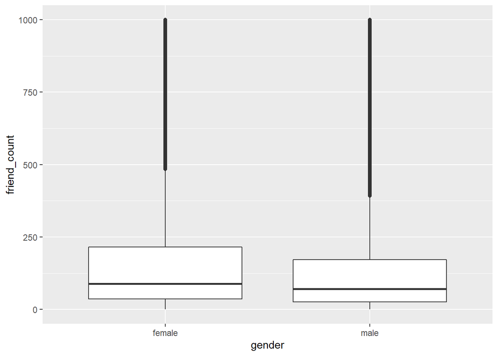

```r
qplot(geom = 'boxplot', ylim=c(0,1000),
      y= friend_count, x=gender,
      data=subset(fb, !is.na(gender)))
```

##or

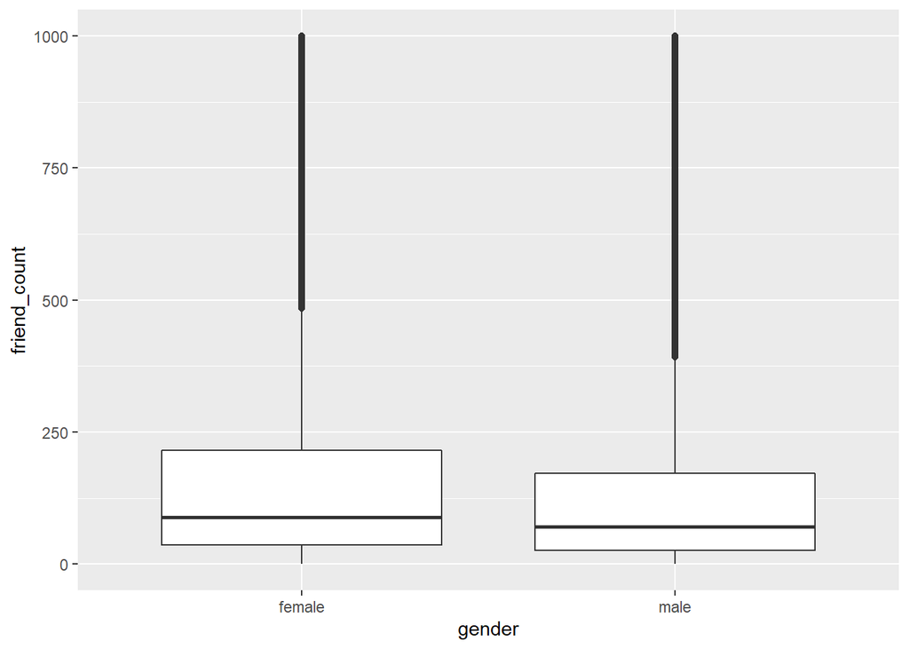

```r
qplot(geom = 'boxplot', data=subset(fb, !is.na(gender)),
      y= friend_count, x=gender )+
  scale_y_continuous(limits = c(0,1000))
```

the problem ylimit or scale_y_continous(limit()) is this that they are removing the data or rows.and it doesnt give us the real box plot. the better approach for that is that we use cartisan:

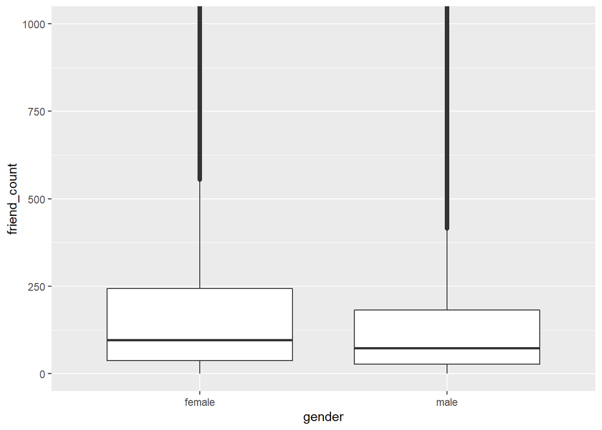

```r
qplot(geom = 'boxplot', data=subset(fb, !is.na(gender)),
      y= friend_count, x=gender )+ coord_cartesian(ylim=c(0,1000))
```

It looks like that female have more friends than men as the median bar is above than the men.

### Box Plots, Quartiles, and Friendships

Notes:

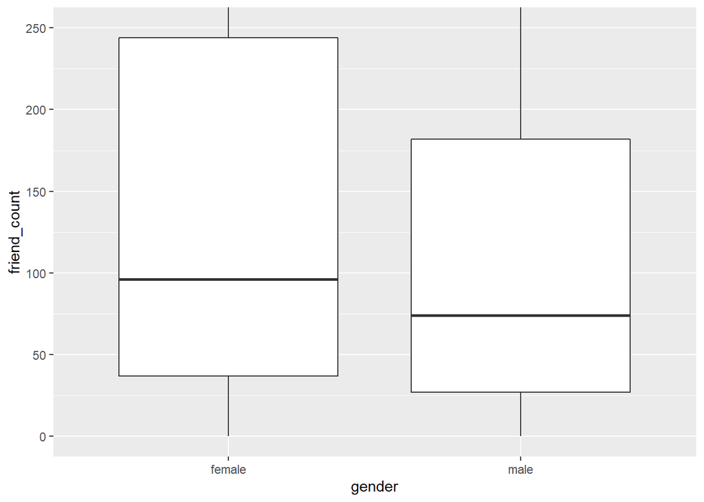

```r
qplot(geom = 'boxplot', data=subset(fb, !is.na(gender)),
      y= friend_count, x=gender )+ coord_cartesian(ylim=c(0,250))
```

```r
by(fb$friend_count, fb$gender, summary)
```

```
## fb$gender: female
##    Min. 1st Qu.  Median    Mean 3rd Qu.    Max.
##       0      37      96     242     244    4923
## ------------------------------------------------------------
## fb$gender: male
##    Min. 1st Qu.  Median    Mean 3rd Qu.    Max.
##       0      27      74     165     182    4917
```

compare this summary with the above boxplot we can say can clearly understand the details. first quartile:25% mark, 25% of the female users have friend_counts less than 37 3rd quartile: 75% mark, means 75% female users have less than 244 friends or 25% of female users have more than 244 friends. same idea can be applied on men plot. another point to be noted is that how the table summary matched to the last boxplot, thanks to the coord-cartisian method.

#### On average, who initiated more friendships in our sample: men or women?

Response:we cant see anything unless we dont see the boxplot

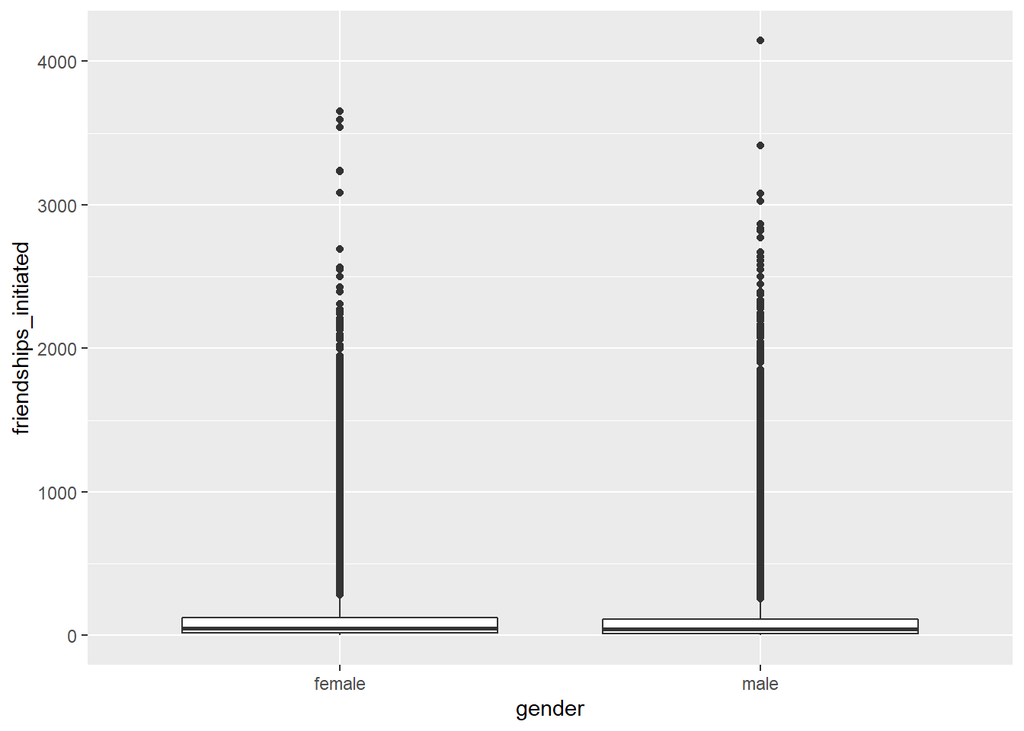

```r
qplot(data=subset(fb, !is.na(gender)), y=friendships_initiated, geom = 'boxplot', x=gender)
```

seeing we can say that most friends have less than 500 friend request.

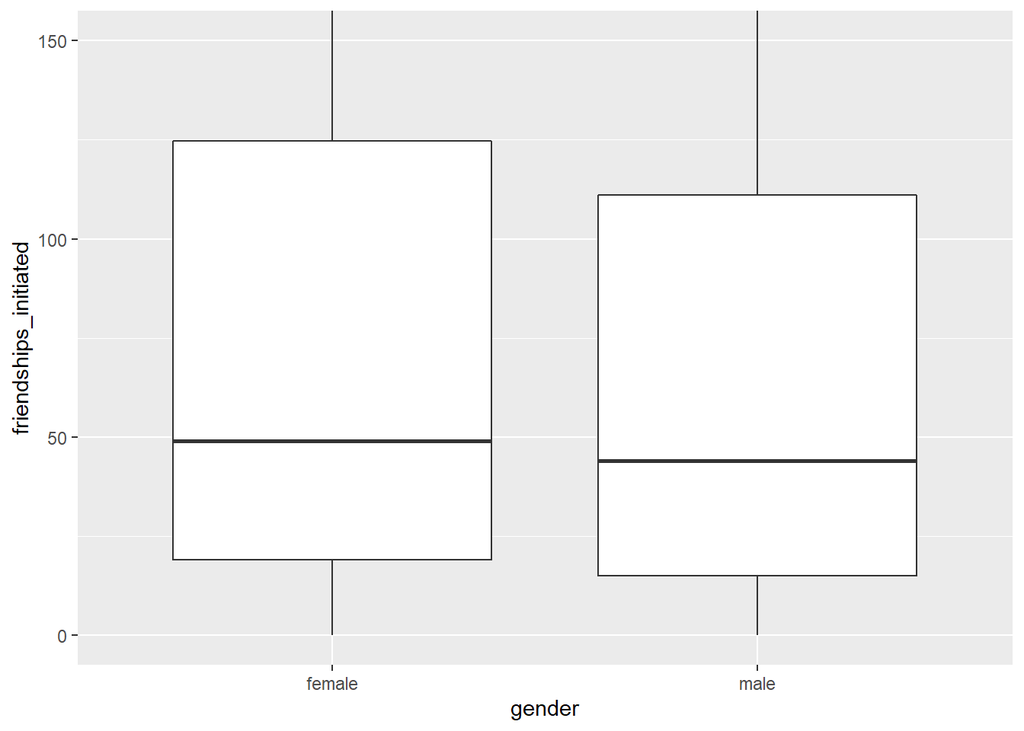

```r
qplot(data=subset(fb, !is.na(gender)), y=friendships_initiated, geom = 'boxplot', x=gender)+
  coord_cartesian(ylim = c(0,150))
```

#### Write about some ways that you can verify your answer.

Response:

```r
by(fb$friendships_initiated, fb$gender, summary)
```

```
## fb$gender: female
##    Min. 1st Qu.  Median    Mean 3rd Qu.    Max.
##     0.0    19.0    49.0   113.9   124.8  3654.0
## ------------------------------------------------------------
## fb$gender: male
##    Min. 1st Qu.  Median    Mean 3rd Qu.    Max.
##     0.0    15.0    44.0   103.1   111.0  4144.0
```

Response: Looking at summary and boxplot we can understand that the number of women on a median level is bigger than men. which means women have initiated more friendship than men

### Getting Logical

Notes: we understood some of the trasnfoeming variable approach. we often want to convert variable that have lots of zero values to a new binary variable that only have true or false: this is helpful, because we may wanna know weather user have used certian feature or not instead of times says the user have used the feature.

```r
summary(fb$mobile_likes)
```

```
##    Min. 1st Qu.  Median    Mean 3rd Qu.    Max.
##     0.0     0.0     4.0   106.1    46.0 25111.0
```

Response: the median is 4 which means we have lots of dataset with zero. lets use comparison operator.

```r
summary(fb$mobile_likes>0)
```

```
##    Mode   FALSE    TRUE
## logical   35056   63947
```

```r
fb$mobile_check_in11= NA
fb$mobile_check_in11= ifelse(fb$mobile_likes>0 ,1,0)
fb$mobile_check_in11= factor(fb$mobile_check_in11)
summary(fb$mobile_check_in11)
```

```
##     0     1
## 35056 63947
```

Note:checking the summer of above we can say that around 64000 are shy of that and checked in heri mobile phones. lets find the percenage of those who used mobile.

```r
sum(fb$mobile_check_in11==1)/length(fb$mobile_check_in11)
```

```
## [1] 0.6459097
```

65% of check in using mobile. its important to understant what kind of data we are looking at. not all transformation are functional, some are like the above example of check in as binary transformation.

### Analyzing One Variable

Reflection:

Click **KnitHTML** to see all of your hard work and to have an html page of this lesson, your answers, and your notes!